# Un breve analisis a la mineria boliviana*

s.a. modificaciones

30/9/2020

## 1. Introducción

Bolivia tiene una historia extensa con la explotación minera, en el siglo pasado el estaño llevaria a un boliviano, Simón Iturri Patiño, a ser uno de los hombres mas ricos del mundo. En la epoca colonial una de las ciudad más acaudaladas de minerales era Potosi, donde se encontraba el famoso Cerro Rico de Potosi al igual que la Casa Reañ de la moneda creada por el virrey del Perú.

En el siglo XX la mineria pasaria a un segundo plano dentro de la economía boliviana siendo remplazada por los hidrocarburos.

Actualmente es necesario hacer un diagnostico de los principales minerales que produce el país y como estos se comportan ante los precios internacionales y al principal pais productor y consumidor de minerales, China. Por lo tanto, se tomara como punto de partida hacer una breve descripción de la producción minera del país y los precios cotizados en la bolsa de Londres. Posteriormente se realizara un sencillo modelo econometrico para hacer inferencia sobre la relación entre la producción minera (especialmente el plomo), ante cambios en los precios internacionales y al crecimiento economico de China.

## 2. Algunos datos relevantes.

Algunos de los minerales que Bolivia produce es el plomo, plata, oro, walfrang, entre otros. Entonces, en las siguientes graficas se ilustran series historicas de la producción de minerales del país.

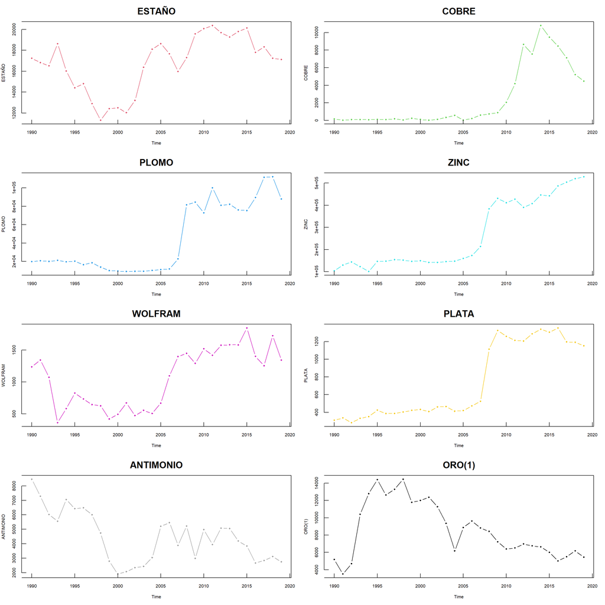

La producción de oro ha descendido desde finales del siglo XX, mientras que los demans minerales han venido incrementanto su producción, a excepcion del antimonio que ha tenido recuperaciones, pero en los ultimos años su producción a decaido. La producción de los minerales plomo, cobre, plata, y zinc han aumentado exponencialmente en los años 2000 a comparación de la ultima decada del milenio pasado, el estaño a recuperado y aumentado la producción que tenia a mediado de los 90.

En las siguientes graficas se exponen las cotizaciones de los minerales de forma anual, se observa que en todos los minerales el precio se incremento con respecto a la ultima decada del milenio anterior, pero desde principio y mediados de esta decada han presentado una disminuciones de sus precios, exceptuando el oro y la plata que han tenido un repunte el ultimo año.

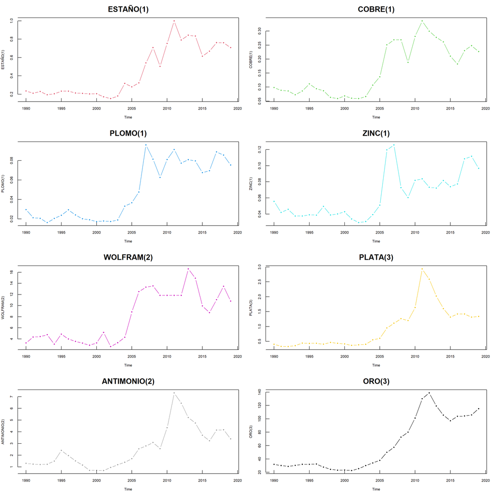

Por otro lado, la producción minera de Bolivia esta predominado por el zinc, plomo y estaño desde los años 90 hasta nuestros dias, tal como lo señala la grafica superior, donde se observa que el 79% de la producción minera se concentra en el zinc, 13% plomo y 5% estaño, el restante entre los demas minerales anteriormente mostrados (excluyendo el oro).

En la grafica inferior se observa la producción minera de 2019, donde los minerales, zinc (82%) y plomo (14%), predominan la producción, los datos fueron extraidos del INE.

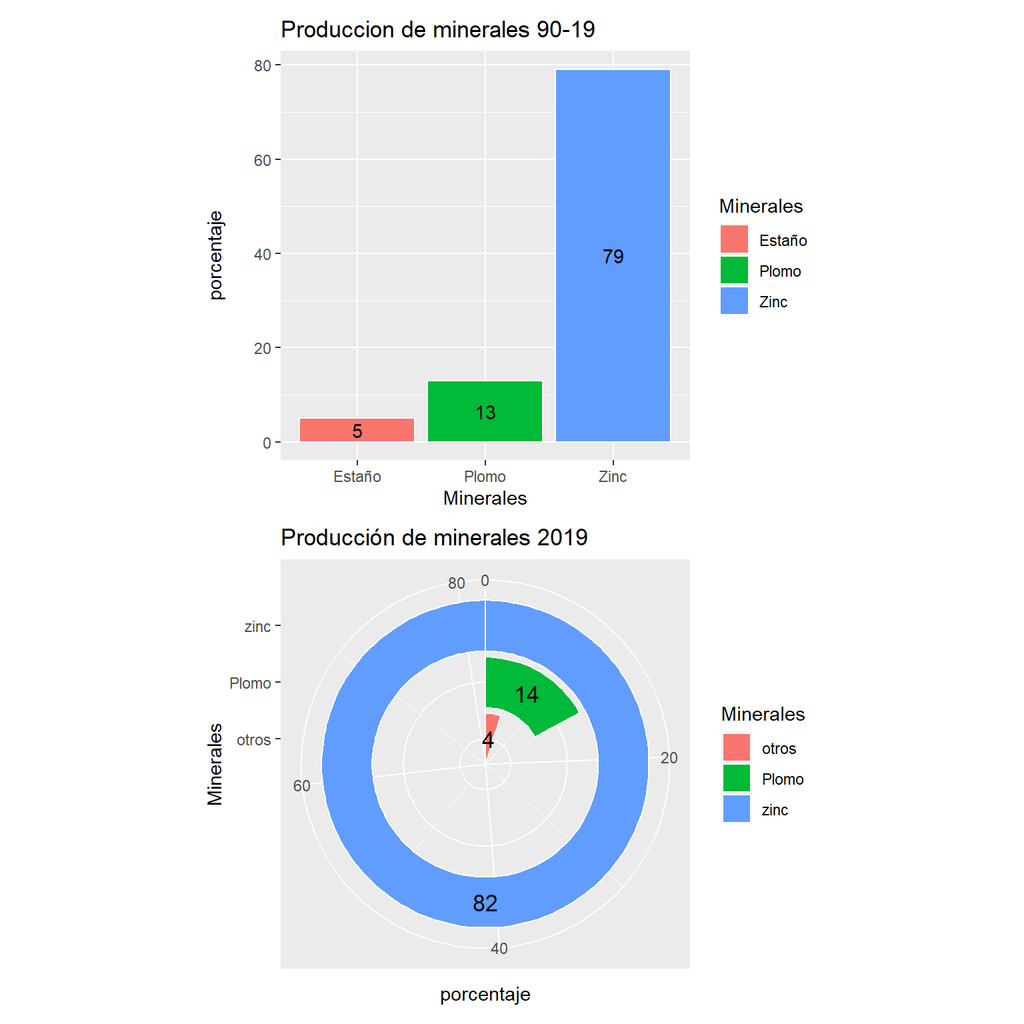

Se podria afirmar que la producción de minerales en Bolivia se divide en dos sectores: I) la mineria chica y cooperativista y II) el sector minero mediano, sin embargo, en el pasado milenio la producción minera bolviana se encontraba un tercer sector, el sector minero estatal. En la grafica siguiente solo ilustraremos la evolución historica del plomo y zinc de los dos primeros, a saber, mineria chica y coooperativista y la mediana.

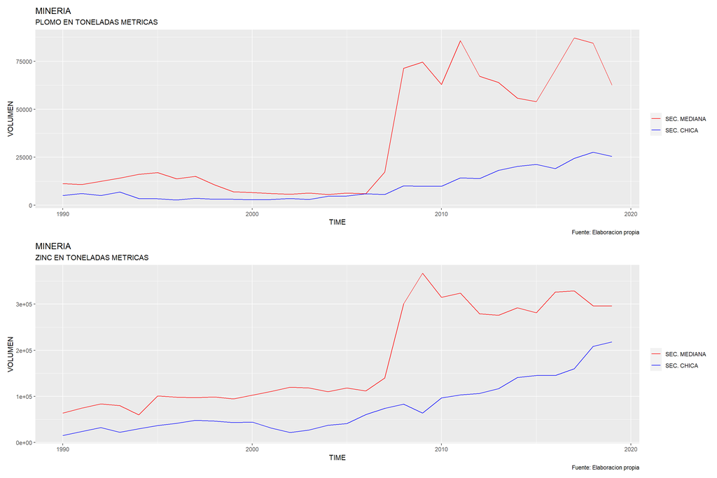

Por otro lado, tambien ilustraremos los 5 paises destino de exportaciones de minerales de Bolivia en el 2019 asi como los departamentos que producen minerales.

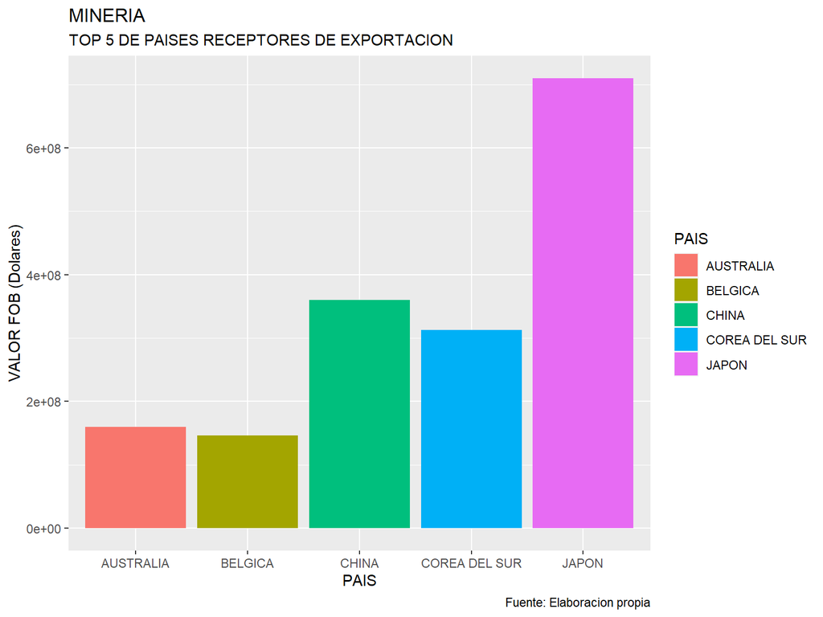

En el siguiente mapa dinamico se ilustra el total de exportaciones de minerales, expresado en FOB (dolares), segun cada ciudad. Se puede observar que la ciudad que mas exporta minerales es Potosi, lo que no es de sorprenderse ya que esta ciudad historicamente ha sido intensiva en mineria desde la epoca colonial.

[interactive chart not shown]

Los 4 paises con mayor producción de plomo, en el año 2012 fueron China, Australia, Estados Unidos y Perú, hasta el 2012 Bolivia era, y es, uno de los principales paises productores de plomo, en la grafica siguiente se muestra las series historicas de la producción de plomo de los primeros 4 paises, en la cual China destaca con un crecimiento exponencial desde mediados de la primera decada del 2000.

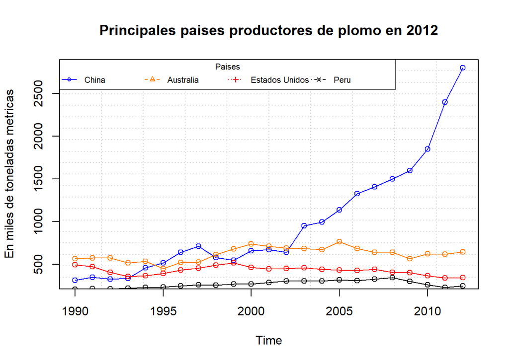

Al igual que el plomo, la producción del zinc ha tenido un notable crecimiento a nivel mundial, aparentemente de una forma mas dinamica que el plomo, como se puede observar en la grafica siguiente.

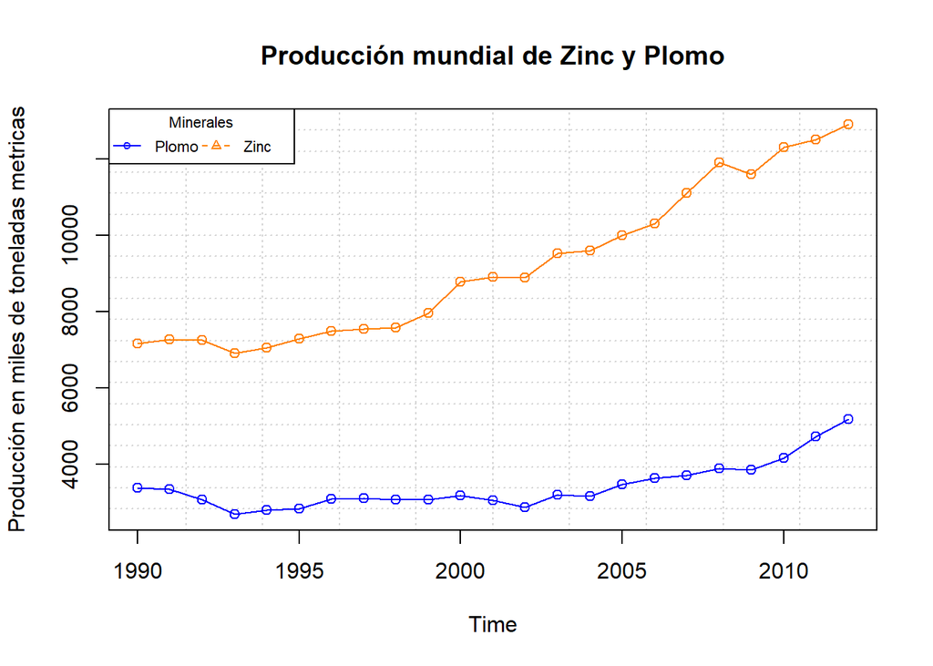

## 3. Una breve inferencia.

Como se observo en la sección anterior, los principales minerales que produce Bolivia son el estaño, plomo y zinc. Por lo tanto, se tomara en cuenta solo el plomo y el zinc para hacer un analisis econometrico sobre la influencia de sus respectivos precios internacionales, por otra parte, se evidencio que los principales paises productores de estos minerales, sobre todo del plomo, son China, Australia y Estados Unidos, de la misma manera se ilustro que los principales paises destino de las exportaciones de minerales bolivianos son Japon, China, Corea del Sur, Australia y Belgica.

Con esta información, se tratara de contrastar la existecia de una relación entre la producción de plomo y el retardo en un periodo (un trimestre) de su respectivo precio internacional, asi como tambien del crecimiento economico de China, Japon, Estados Unidos y la Union Europea, esta ultima ingresa al analisis por la relevancia que evidentemente tiene en la economia mundial.

Se espera que todas las variables seas positivas, es decir, que las variables independientes expuestas anteriormente tengan un efecto directo sobre la producción del plomo. La logica es sencilla, a mayores precios, mayor producción, a mayor crecimiento economico de los principales paises desarrollados mayor producción de minerales. Sin embargo, se podria esperar una relación inversa con los principales paises productores de estos commodities, dado que tambien estos pueden aumentar su producción e influenciar en el mercado de estos producctos, el analisis sobre es aspecto escapa de este breve escrito, nos limitamos a indicar la existencia de esta relación inversa.

De la misma manera, utilizaremos la logica anteriormente descrita para la producción de zinc.

## 3.1 Sobre las variables.

Como se menciono en la anterior sección las varibles son:

- Producción nacional de plomo, esta variable es transformada a tasas de crecimiento, la información fue usbtraida del [Instituto Nacional de estadistica - INE](https://www.ine.gob.bo/). En los cuadros de resultados se lo apreciara abreviadamente como `Pd.p`.
- Producción nacional de zinc, esta variable es transformada a tasas de crecimiento, la información fue usbtraida del [Instituto Nacional de estadistica - INE](https://www.ine.gob.bo/). En los cuadros de resultados se lo apreciara abreviadamente como `Pd.z`.
- Cotización de los precios internacionales del plomo, esta variable es transformada a tasas de crecimiento, la información fue substraida de Pink Sheet, [World Bank](https://www.bancomundial.org/). En los cuadros de resultados se lo apreciara abreviadamente como `Pc.p`.
- Cotización de los precios internacionales del zinc, esta variable es transformada a tasas de crecimiento, la información fue substraida de Pink Sheet, [World Bank](https://www.bancomundial.org/). En los cuadros de resultados se lo apreciara abreviadamente como `Pc.z`.
- PIB real de Estados Unidos, esta variable es transformada a tasas de crecimiento. la fuente de los datos es [Federal Reserve Bank of St. Louis](https://www.stlouisfed.org/). En los cuadros de resultados se lo apreciara abreviadamente como `Gdp.usa`.
- PIB real de Japon, esta variable es transformada a tasas de crecimiento. la fuente de los datos es [Federal Reserve Bank of St. Louis](https://www.stlouisfed.org/). En los cuadros de resultados se lo apreciara abreviadamente como `Gdp.jap`.
- PIB real de China, esta variable es transformada a tasas de crecimiento, la fuente de los datos es Chang C., K. Chen, D. Waggoner, and T. Zha, “Trends and Cycles in China’s Macroeconomy,” NBER Macroeconomics Annual Vol 30, 2016, 1-84, University of Chicago Press. Encontrado en [Federal Reserve Bank of St. Louis de la pagina de Federal Reserve Bank of Atlanta](https://www.frbatlanta.org/). En los cuadros de resultados se lo apreciara abreviadamente como `Gdp.chi`.
- PIB real de la Unión Europea, esta variable es transformada a tasas de crecimiento, la fuente de los datos es [Eurostat](https://ec.europa.eu/eurostat/home?). En los cuadros de resultados se lo apreciara abreviadamente como `Gdp.ue`.

Los datos son trimestrales y comprenden de 1996 a 2019, todos fueron encontrados ajustados por estacionalidad.

En la siguiente tabla se presenta los estadisticos descriptivos de cada variable.

**Descriptive statistics**

| Statistic | N | Mean | St. Dev. | Min | Pctl(25) | Pctl(75) | Max |
| --- | --- | --- | --- | --- | --- | --- | --- |
| Pd.p | 97 | 0.02 | 0.2 | -0.3 | -0.1 | 0.1 | 0.8 |
| Pc.p | 97 | 0.01 | 0.1 | -0.4 | -0.1 | 0.1 | 0.4 |
| Pd.z | 97 | 0.02 | 0.1 | -0.2 | -0.03 | 0.1 | 0.4 |
| Pc.z | 97 | 0.01 | 0.1 | -0.4 | -0.05 | 0.1 | 0.4 |
| Gdp.aus | 97 | 0.01 | 0.01 | -0.01 | 0.004 | 0.01 | 0.03 |
| Gdp.chi | 97 | 0.02 | 0.01 | 0.001 | 0.02 | 0.02 | 0.04 |
| Gdp.usa | 97 | 0.01 | 0.01 | -0.02 | 0.004 | 0.01 | 0.02 |
| Gdp.ue | 97 | 0.004 | 0.01 | -0.03 | 0.003 | 0.01 | 0.01 |
| Gdp.jap | 97 | 0.002 | 0.01 | -0.05 | -0.001 | 0.01 | 0.02 |

## 3.2 Modelo de Corto plazo del Plomo.

Se presenta solo el modelo de corto plazo, ya que despues de estudiar una posible relación de largo plazo a traves de un analisis de cointegración, no existio evidencia empirica que sustente tal relación.

Entonces, al correr el modelo con las variable mencionadas en la sección anterior obtuvimos que la unica variable significativa era el retardo de `Pc.p` (Precio del plomo), y que el modelo no era significativo de manera global.

|  | *Dependent variable:* |
| --- | --- |
|  | Pd.p |
| lag(Pc.p) | 0.452** |
|  | (0.175) |
| lag(Gdp.usa) | -3.668 |
|  | (3.724) |
| lag(Gdp.chi) | 0.607 |
|  | (2.965) |
| lag(Gdp.ue) | -0.243 |
|  | (4.423) |
| lag(Gdp.aus) | 2.555 |
|  | (2.298) |
| lag(Gdp.jap) | -1.750 |
|  | (2.303) |
| Constant | 0.001 |
|  | (0.067) |
| Observations | 96 |
| R<sup>2</sup> | 0.100 |
| Adjusted R<sup>2</sup> | 0.039 |
| Residual Std. Error | 0.178 |
| F Statistic | 1.648 |
| *Note:* | p<0.1; p<0.05; p<0.01 |

| Modelo de corto plazo para el plomo |
| --- |

Por consiguiente se realiza un analisis ANOVA y se elimina la variable con menor influencia, que en este caso fue `Gdp.ue`, tal como se presenta en la tabla siguiente:

**Analisis de la Varianza**

|  | Sum Sq | Df | F value | Pr(> F) |
| --- | --- | --- | --- | --- |
| lag(Pc.p) | 0.213 | 1 | 6.706 | 0.011 |
| lag(Gdp.usa) | 0.031 | 1 | 0.970 | 0.327 |
| lag(Gdp.chi) | 0.001 | 1 | 0.042 | 0.838 |
| lag(Gdp.ue) | 0.0001 | 1 | 0.003 | 0.956 |
| lag(Gdp.aus) | 0.039 | 1 | 1.236 | 0.269 |
| lag(Gdp.jap) | 0.018 | 1 | 0.577 | 0.449 |
| Residuals | 2.829 | 89 |  |  |

Por lo tanto el modelo corregido es el siguiente, el cual si cumple todos los supuestos de MCRL y en el cual se verifica que en esta ocación el modelo es globalmente significativo. Nuevamente todas las variables no son significativas a excepción de `Pc.p`.

**La interpretación del modelo es: un aumento de 1% en los precios del trimestre anterior aumenta en la producción del plomo boliviano en un 0.451%.**

|  | *Dependent variable:* |
| --- | --- |
|  | Pd.p |
| lag(Pc.p) | 0.451** |
|  | (0.172) |
| lag(Gdp.usa) | -3.750 |
|  | (3.394) |
| lag(Gdp.chi) | 0.625 |
|  | (2.929) |
| lag(Gdp.aus) | 2.527 |
|  | (2.229) |
| lag(Gdp.jap) | -1.803 |
|  | (2.079) |
| Constant | 0.0003 |
|  | (0.065) |
| Observations | 96 |
| R<sup>2</sup> | 0.100 |
| Adjusted R<sup>2</sup> | 0.050 |
| Residual Std. Error | 0.177 |
| F Statistic | 1.999* |
| *Note:* | p<0.1; p<0.05; p<0.01 |

| Modelo de corto plazo para el plomo |
| --- |

## 3.3 Modelo de Corto plazo del Zinc.

Al igual que la sección anterior, se presenta solo el modelo de corto plazo, ya que despues de estudiar una posible relación de largo plazo a traves de un analisis de cointegración, no existio evidencia empirica que sustente tal relación.

Por lo tanto en la siguiente tabla se presenta el modelo con las variables ya mencionadas en la sección 3.1, se evidencia que ni `Pc.z` es estadisticamente significativa y que el modelo globalmente no es significativo.

|  | *Dependent variable:* |
| --- | --- |
|  | Pd.z |
| lag(Pc.z) | -0.024 |
|  | (0.080) |
| lag(Gdp.usa) | -1.955 |
|  | (1.853) |
| lag(Gdp.chi) | 1.985 |
|  | (1.380) |
| lag(Gdp.ue) | 0.893 |
|  | (2.149) |
| lag(Gdp.aus) | 0.178 |
|  | (1.125) |
| lag(Gdp.jap) | -1.627 |
|  | (1.128) |
| Constant | -0.019 |
|  | (0.031) |
| Observations | 96 |
| R<sup>2</sup> | 0.058 |
| Adjusted R<sup>2</sup> | -0.005 |
| Residual Std. Error | 0.087 |
| F Statistic | 0.915 |
| *Note:* | p<0.1; p<0.05; p<0.01 |

## 4. Conclusión.

Se concluye que en modelo de corto plazo del plomo solo existe una variable que es signifiva, y es el precio del plomo, y cuya relación es positiva. Por otro lado, para el modelo de corto plazo del zinc no se encontro evidencia de una posible relación entre las variables. En ambos modelos ser rechaza la prueba de cointegración.

## 5. Anexos.

- Ver Sript **Minerales.R**